# Construindo um modelo e API para previsão dos preços de imóveis em Teresina - PI

Author

Prof. Dr. Pedro Rafael Diniz Marinho

# Modelagem imobiliária para dados de imóveis em Teresina - PI

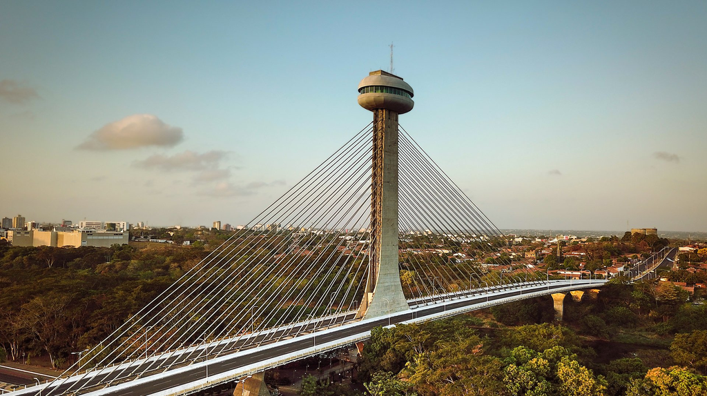

Iremos construir um modelo para previsão de valores 💲de imóveis usando o framework [**tidymodels**](https://www.tidymodels.org/) e disponibilizar uma API para consulta (previsão) dos preços de imóveis em Teresina - PI.

1. Construção do modelo
2. Criação de uma imagem [Docker](https://www.docker.com/) 🐋
3. Executar um container 🚢 + 📦 com a API [vetiver](https://vetiver.posit.co/)
4. Consulta da API 🌐

## Olhando para os dados

São dados reais, obtidos via web scraping do site [**Zap Imóveis**](https://www.zapimoveis.com.br/) 🏡🏢 no ano de 2023 do município de Teresina, Piauí, Brasil.

**Você poderá acessar os dados clicando** **AQUI** 💾.

```r
library(vroom) # Leitura dos dados
library(janitor) # Limpando nomes das colunas
library(dplyr) # Manipulação de dados
# Base de dados dos imóveis anuanciados em Teresina (2023)
dados <- vroom::vroom("teresina.csv") |>
  janitor::clean_names() # Organizando os nomes das colunas
# Visualizando os dados com o comando glimpse
dplyr::glimpse(dados)
```

```
Rows: 8,104
Columns: 27
$ id                        <dbl> 2628381702, 2632203837, 2569578780, 26263159…
$ endereco                  <chr> "Aeroporto", "Aeroporto", "Aeroporto", "Pra+…
$ valor                     <dbl> 550000, 700000, 250000, 370000, 700000, 7000…
$ area                      <dbl> 500, 146, 250, 220, 200, 200, 200, 200, 200,…
$ iptu                      <dbl> NA, NA, NA, 1, 1, 1, 1, 1, 1, 1, 1, NA, NA, …
$ condominio                <dbl> NA, NA, NA, 1, 300, NA, 450, 400, 500, 350, …
$ quarto                    <dbl> 2, 3, 2, 4, 3, 3, 3, 3, 3, 3, 3, 3, 5, 3, 3,…
$ vaga                      <dbl> 1, 4, 1, 2, 2, 2, 2, 2, 2, 2, 2, 5, 4, 2, 2,…
$ banheiro                  <dbl> 2, 4, 2, 2, 3, 3, 3, 3, 3, 3, 3, 3, 4, 3, 3,…
$ url                       <chr> "https://www.zapimoveis.com.br/venda/casas/p…
$ bairro                    <chr> "aeroporto", "aeroporto", "aeroporto", "aero…
$ tipo                      <chr> "casas", "casas", "casas", "casas", "casas",…
$ area_af8_servico          <lgl> FALSE, FALSE, TRUE, FALSE, FALSE, FALSE, FAL…
$ espaco_af8_gourmet        <lgl> FALSE, FALSE, FALSE, FALSE, FALSE, FALSE, FA…
$ piscina                   <lgl> FALSE, FALSE, FALSE, FALSE, TRUE, TRUE, TRUE…
$ elevador                  <lgl> FALSE, FALSE, FALSE, FALSE, FALSE, FALSE, FA…
$ salao_af8_de_af8_festa    <lgl> FALSE, FALSE, FALSE, FALSE, FALSE, FALSE, FA…
$ academia                  <lgl> FALSE, FALSE, FALSE, FALSE, FALSE, FALSE, FA…
$ playground                <lgl> FALSE, FALSE, FALSE, FALSE, FALSE, FALSE, FA…
$ quadra_af8_de_af8_esporte <lgl> FALSE, FALSE, FALSE, FALSE, FALSE, FALSE, FA…
$ portaria_af8_24_af8_horas <lgl> FALSE, FALSE, FALSE, FALSE, FALSE, FALSE, FA…
$ varanda_af8_gourmet       <lgl> FALSE, FALSE, FALSE, FALSE, FALSE, TRUE, FAL…
$ sauna                     <lgl> FALSE, FALSE, FALSE, FALSE, FALSE, FALSE, FA…
$ spa                       <lgl> FALSE, FALSE, FALSE, FALSE, FALSE, FALSE, FA…
$ comercio                  <lgl> FALSE, FALSE, FALSE, FALSE, FALSE, FALSE, FA…
$ latitude                  <chr> "+AC0-5.06564999999995", "+AC0-5.06564999999…
$ longitude                 <chr> "+AC0-42.8164599999999", "+AC0-42.8164599999…
```

Vamos agora visualizar os dados de uma forma que facilite a compreensão.

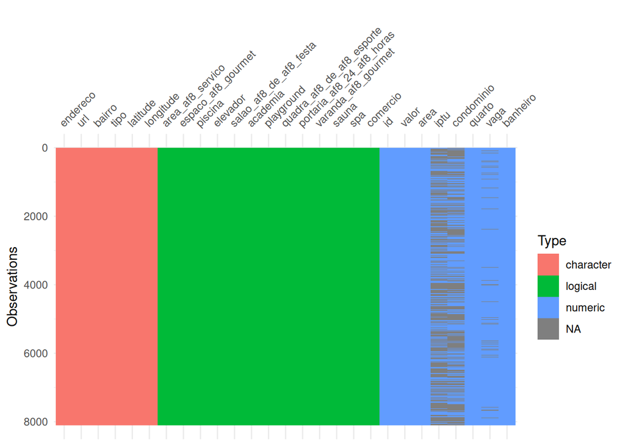

```r
library(visdat)
library(dplyr)
# Visualizando os dados (tipo, estrutura e valores ausentes)
visdat::vis_dat(dados)
```

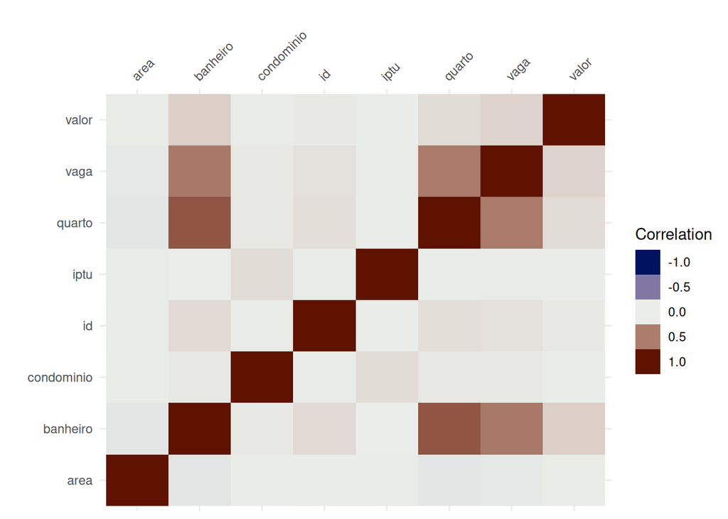

```r
# Selecionando apenas as variáveis numéricas
dados |>
  dplyr::select(where(is.numeric)) |>
  visdat::vis_cor(digits = 2, sort = TRUE)
```

Vamos observar os tipos de imóveis na variável `tipo` e fazer uma contagem nos tipos disponíveis:

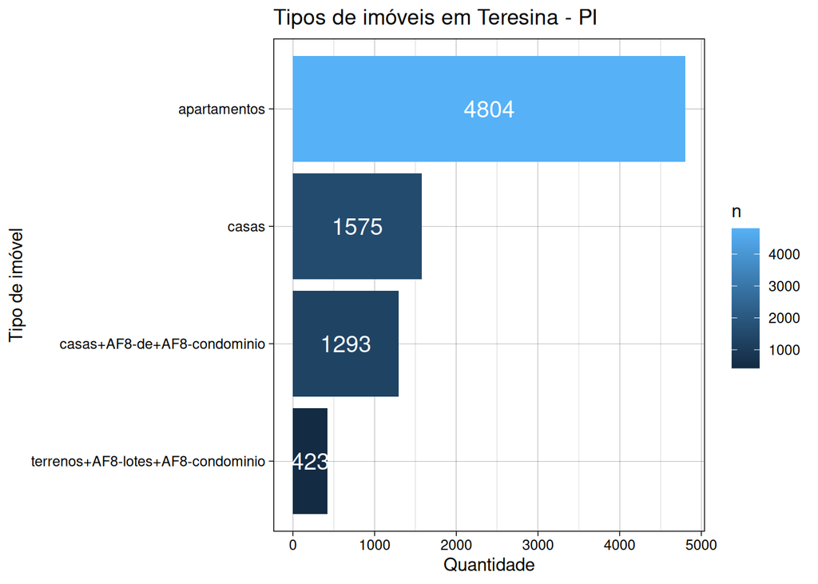

```r
# Tabela com a quantidade de tipos de imóveis
library(ggplot2)
library(dplyr)

# Contagem de tipos de imóveis
tipos_imoveis <-
  dados |>
  dplyr::count(tipo) |>
  dplyr::arrange(desc(n))

# Verificando os tipos de imóveis
p1 <-
  tipos_imoveis[1:4, ] |>
  dplyr::arrange(desc(n)) |>
  dplyr::mutate(tipo = forcats::fct_reorder(tipo, n)) |>
  ggplot(aes(x = tipo, y = n)) +
  geom_col(aes(fill = n)) +
  coord_flip() +
  geom_text(
    aes(label = n),
    position = position_stack(vjust = 0.5),
    color = "white",
    size = 5
  ) +
  labs(
    title = "Tipos de imóveis em Teresina - PI",
    x = "Tipo de imóvel",
    y = "Quantidade"
  ) +
  theme_linedraw()
# Gráfico com os tipos de imóveis
print(p1)
```

```r
# Tabela com os tipos de imóveis
print(tipos_imoveis)
```

```
# A tibble: 6 × 2
  tipo                                  n
  <chr>                             <int>
1 apartamentos                       4804
2 casas                              1575
3 casas+AF8-de+AF8-condominio        1293
4 terrenos+AF8-lotes+AF8-condominio   423
5 flat                                  8
6 casas+AF8-de+AF8-vila                 1
```

Observa-se que as informações do `iptu` e `condiminio` são muito incipientes, e talvez, inputar essas informações não seja uma boa ideia, pois pode gerar um viés no modelo. Vamos descartar essas variáveis.

**Lista de veriáveis que serão descartadas:**

1. `endereço`: já há o georeferenciamento dos imóveis
2. `url`: sem utilidade para a previsão
3. `bairro`: já há o georeferenciamento dos imóveis
4. `iptu`: muitas observações faltantes
5. `condominio`: muitas observações faltantes

```r
# Dados gerais com a remoção das variáveis que não serão utilizadas
dados <- dados |>
  dplyr::select(
    -iptu,
    -condominio,
    -endereco,
    -url,
    -bairro
  )

# Agrupando casas = casas + casas_de_condimonio + casas_de_vila e
# apartamentos = apartamentos + flat
dados <- dados |>
  dplyr::mutate(
    tipo = dplyr::case_when(
      tipo == "casas" ~ "casa",
      tipo == "casas_de_condiminio" ~ "casa",
      tipo == "casas_de_vila" ~ "casa",
      tipo == "apartamentos" ~ "apartamento",
      tipo == "flat" ~ "apartamento",
      TRUE ~ tipo # Se houver outro tipo, manter o mesmo valor
    )
  ) |>
  dplyr::filter(tipo %in% c("casa", "apartamento"))

# Contagem de tipos de imóveis
tipos_imoveis <- dados |>
  dplyr::count(tipo) |>
  dplyr::arrange(desc(n))

print(tipos_imoveis)
```

```
# A tibble: 2 × 2
  tipo            n
  <chr>       <int>
1 apartamento  4812
2 casa         1575
```

# Realizando a divisão dos dados holdout

```r
library(tidymodels)
library(future)

# Resolvendo conflitos de pacotes
tidymodels::tidymodels_prefer()

# Configurando o plano de execução para paralelização
# (Unix/Linux e Windows)
future::plan("multisession")

# Fixando uma semente para garantir a reprodutibilidade
set.seed(123)
dados_split <- dados |>
  rsample::initial_split(prop = 0.8, strata = tipo)

treino <- rsample::training(dados_split)
teste <- rsample::testing(dados_split)

receita <- treino |>
  recipes::recipe(valor ~ ., data = treino) |>
  recipes::step_impute_knn(all_numeric(), neighbors = tune("k")) |>
  recipes::step_log(all_numeric()) |>
  recipes::step_zv(all_predictors())

# Criando o conjunto de validação cruzada e estratificando por tipo de imóvel
cv <- rsample::vfold_cv(treino, v = 5, strata = tipo)
```